# GEOG 5680 6680 12 Spatial data in R

### SpatialPolygonDataFrame Objects

We’ll now replot the Syracuse shapefile with a better color palette. We’ll add an additional function `classIntervals()`, which can be used to change the intervals in a color palette. By default, these are even splits (so each interval covers the same range). If your variable is skewed, then other splits may be better. The `style` argument allows to choose different types of split. Here, we’ll use percentiles, which acts in a similar way to a histogram normalization of the variable. Note that we now have three lines of code to make the plot:

- Make the color palette
- Create the intervales
- Make the plot. Note the use of the `at` argument, which sets the breaks to those defined by `classIntervals()`

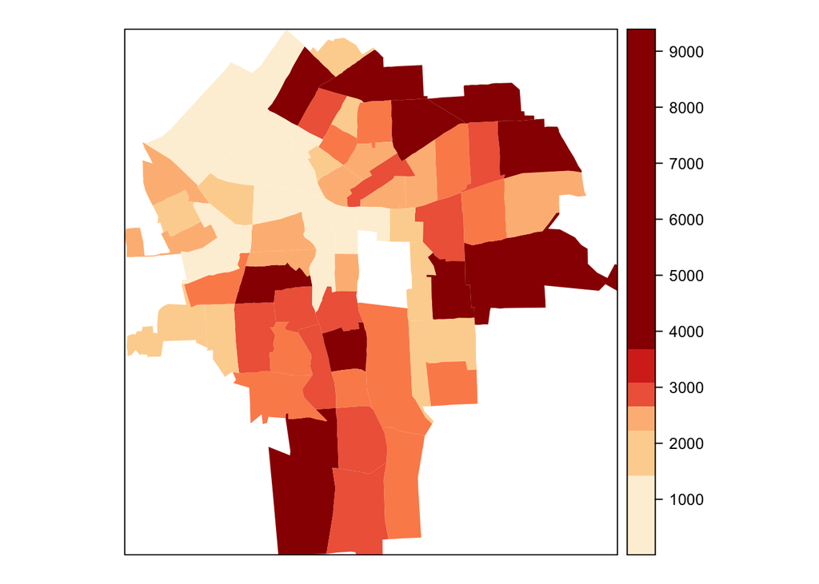

```r
library(classInt)
my.pal <- brewer.pal(n = 7, name = "OrRd")
breaks.qt <- classIntervals(Syracuse$POP8, n = 6, style = "quantile")
spplot(Syracuse, "POP8", col.regions = my.pal, col = "transparent",
       at = breaks.qt$brks)
```

### SpatialGridDataFrame Objects

And finally an example with a gridded dataset. This is the Swiss DEM used above. We’ll also load a shapefile with the Switzerland borders:

```r
swiss.bord = readOGR("borders/borders.shp")
my.pal <- rev(brewer.pal(n = 9, name = "Greens"))
breaks.qt <- classIntervals(swiss.dem$elev, n = 8, style = "quantile")
```

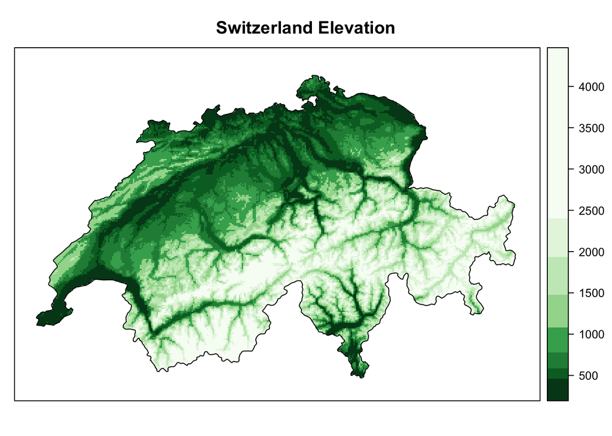

```r
spplot(swiss.dem, "elev", main="Switzerland Elevation",
       sp.layout=list(swiss.bord), col.regions = my.pal, at = breaks.qt$brks)
```

## The **raster** package

The **raster** package offers a array of functions for dealing with gridded data, including the ability to read from many widely used file formats, including remote sensing images (e.g. GeoTiffs) and NetCDF and HDF formats. We will use it here to work with gridded air temperature data (*air.mon.ltm.nc*) from the [NCAR NCEP reanalysis project](http://www.esrl.noaa.gov/psd/data/reanalysis/reanalysis.shtml). This is the long term means for each month from 1981-2010. The file has 12 layers (one per month) and one variable (*air*).

### Raster objects

Start by installing and loading the package, the use the `raster()` function to read from the file.

```r
library(raster)
r = raster("air.mon.ltm.nc")
```

Note that we have only read the first layer (January). R will tell you that it loaded the variable called *air*. To avoid this message you can specify this directly, which is important for files containing multiple variables:

```r
r = raster("air.mon.ltm.nc", varname="air")
r
```

```
## class      : RasterLayer
## band       : 1  (of  12  bands)
## dimensions : 73, 144, 10512  (nrow, ncol, ncell)
## resolution : 2.5, 2.5  (x, y)
## extent     : -1.25, 358.75, -91.25, 91.25  (xmin, xmax, ymin, ymax)
## crs        : NA
## source     : /Users/u0784726/Dropbox/DB Docs/Classes/GEOG5680/Modules/12 Spatial data in R/air.mon.ltm.nc
## names      : Monthly.Long.Term.Mean.Air.Temperature.at.sigma.level.0.995
## z-value    : 0000-12-30
## zvar       : air
```

`r` is a raster object and has information about grid spacing, coordinates etc. Note that the description of the object tells you whether it is held in memory (small raster files) or on disk. We can make a simple plot:

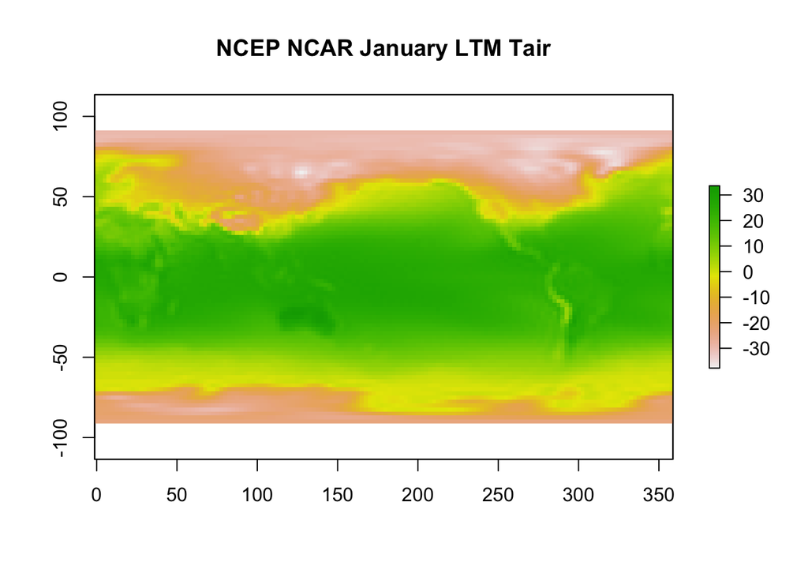

```r
plot(r, main="NCEP NCAR January LTM Tair")
```

And you should be able to see the outline of the continents. By default, NCAR NetCDF files have longitudes running from 0 to 360. We can convert this to the more commonly used (and UK-centric :) -180 to 180 by the function `rotate()`. We can also use a different color palette and add the country shapefile we loaded earlier:

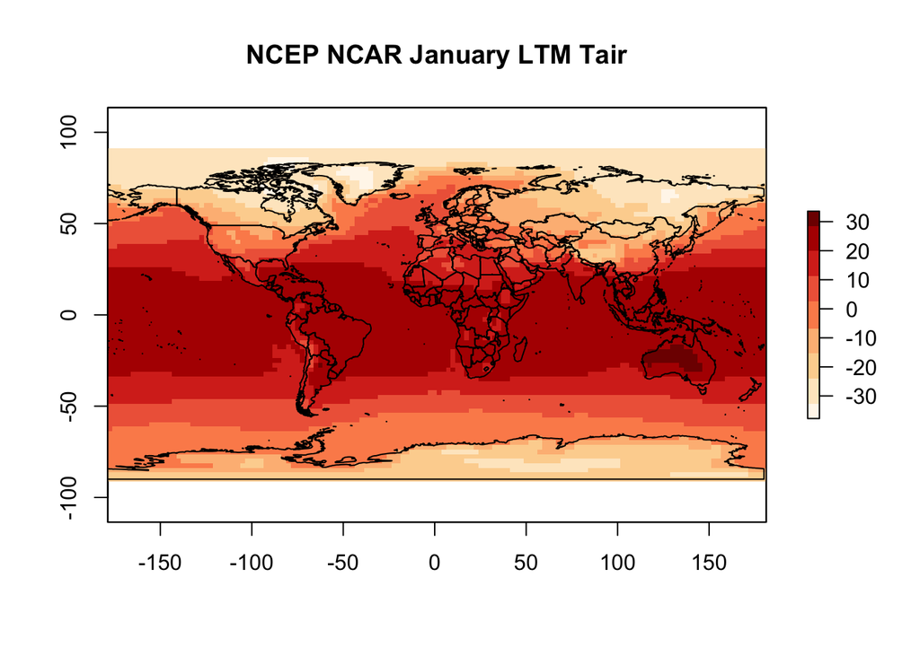

```r
r = rotate(r)
my.pal <- brewer.pal(n = 9, name = "OrRd")
plot(r, main="NCEP NCAR January LTM Tair", col=my.pal)
plot(countries, add=TRUE)
```

The function `cellStats()` can be used to calculate most summary statistics for a raster layer. So to get the mean global temperature (and standard deviation):

```r
cellStats(r, mean)
cellStats(r, sd)
```

Values can be extracted from individual locations (or sets of locations) using `extract()`. This can take a set of coordinates in matrix form, or use a Spatial* object. To get the January temperature of Salt Lake City:

```r
extract(r, cbind(-111.9,40.76))
```

By default this gives you the value of the cell in which the point falls. The value can equally be estimated by bilinear interpolation from the four closest cells with `method='bilinear'`:

```r
extract(r, cbind(-111.9,40.76), method='bilinear')
```

We created a SpatialPoints object earlier with the location of samples in Western North America (`wnaclim.spdf`). We can now use this, and the raster layer to get the January temperature for all locations:

```r
extract(r, wnaclim.spdf, method='bilinear')
```

If we want to use only a subset of the original raster layer, the function `crop()` will extract only the cells in a given region. This can be defined using another raster object or Spatial* object, or more simply by defining an `extent` object:

```r
myext = extent(c(-130,-60,24,50))
r = crop(r, myext)
plot(r, main="NCEP NCAR January LTM Tair", col=my.pal)
plot(countries, add=TRUE)
```

### Raster Stacks

A useful extension to the basic raster functions is the use of stacks. These are a stack of raster layers which represent different variables, but have the same spatial extent and resolution. We can then read in and store all 12 months from the NetCDF file, and then work with this. We read these in with `stack()` and crop them as before:

```r
myext = extent(c(-130,-60,25,50))
r.stk = rotate(stack("air.mon.ltm.nc", varname="air"))
r.stk = crop(r.stk, myext)
r.stk
```

By typing the name of the stack object, we can see that this has 12 layers, each with 280 cells and the extent, etc. The names attributed to each layer are often unreadable, so we can add our own names:

```r
names(r.stk) <- paste("TAS",month.abb)
names(r.stk)
```

Now any of the functions we used previously with one layer will be used across all layers. The `plot()` function returns a grid with one plot per layer. Setting the `zlim` argument ensures that all figures use the same range of colors:

```r
plot(r.stk, col=my.pal, zlim=c(-35,35))
```

Adding a shapefile (or other spatial information) is a little more complex. We create a simple function to plot the country borders, then include this as an `addfun` in the call to `plot()`:

```r
addBorder = function(){ plot(countries, add=TRUE) }
plot(r.stk, zlim=c(-35,35), col=my.pal, addfun=addBorder)
```

The `cellStats()` function now returns the mean (or other statistic) for all layers, allowing a quick look at the seasonal cycle of average air temperature.

```r
tavg = cellStats(r.stk, mean)
plot(1:12, tavg, type='l', xlab="Month", ylab="Avg T (C)")
```

And we can do the same for an individual location using `extract()`:

```r
slc.tavg = extract(r.stk, cbind(-111.9,40.76), method='bilinear')
plot(1:12, slc.tavg, type='l', xlab="Month", ylab="Avg T (C)")
```

This same approch allows you to extract pixels by polygon overlays. Let’s re-read the global dataset, and try extracting values for a given country. First, we’ll extract China’s polygon as a new SpatialPolygon, then use this in the `extract()` function to get all the pixels within the borders

```r
r = rotate(raster("air.mon.ltm.nc"))
china.sp = subset(countries, NAME == "China")
extract(r, china.sp)
```

As this function can be used with a set of polygons, the output is in a list. We can use extract the first value of this list, and make a quick histogram:

```r
china.tjan = extract(r, china.sp)[[1]]
hist(china.tjan)
```

The `extract()` function also takes an argument `fun`. This allows you to calculate a summary statistic for each set of pixels that is extracted (i.e. one per polygon). Here, we’ll use this with the countries SpatialPolygon to get an average value of January temperature. We add this back as a new column in the countries object, and then plot it:

```r
countries$Jan_Tmp = extract(r, countries, fun = mean)[,1]
spplot(countries, "Jan_Tmp", main = "Country average January temperature")
```

## Other spatial functionality

### R and KML files

R can write out KML files for use with Google Earth. A few things to note here:

- The function is `kmlPoints()` from the **maptools** package (there are also functions for KML polygons and lines)
- The function requires a Spatial* object (here a SpatialPointsDataFrame), and the name of an output file
- Optionally we can provide a layer name (`kmlname`) and a vector of names for each point (`name`)
- The optional parameter `description` associates some descriptive text with each point, including HTML tags.
  - Here we create a series of descriptions that include the January and July temperatures, together with text labels.
  - Note the use of the `paste()` function to glue together different text strings (which can include numeric vectors)

The second function writes out the points and descriptions into a KML file in the current working directory. Once run, find this file and open it in Google Earth. You can replace the icon using any of the icons found [here](https://sites.google.com/site/gmapsdevelopment/).

```r
description = paste("<b>TJan:</b>", wnaclim.spdf$Jan_Tmp,
                    "<br><b>TJul:</b>", wnaclim.spdf$Jul_Tmp)
kmlPoints(wnaclim.spdf,"test.kml", kmlname="WNAclim",
          name=wnaclim$WNASEQ, description=description,
          icon="http://www.google.com/mapfiles/kml/paddle/wht-diamond.png")
```

Here’s a second example, with polygon data (the Syracuse polygons). Note that as these are in a UTM projection, we need to reproject to latitude/longitude coordinates, then can write out to a KML file:

```r
ll.proj <- "+proj=longlat +ellps=WGS84"
Syracuse.proj <- spTransform(Syracuse, CRS(ll.proj))

kmlPolygons(Syracuse.proj, kmlfile = "syr.kml",
            col="white", border="black", lwd=3)
```

## Exercises

### Exercise 1

In the zipfile *countries.zip* is a global shapefile with various socio-economic indicators for different countries. Load this file into R and make plots of any of the following variables (the variable names are given in brackets). Try different color scales and transformations of the data to get the most informative maps

- Median GDP: (`gdp_md_est`)
- Population: (`pop_est`)
- Income group: (`income_grp`)

### Exercise 2

The NetCDF file *air.mon.mean.nc* contains air temperature data from the NCAR NCEP project, but as mean monthly temperature for every year between 1948 and the present. Using the functions introduced in this lab, read in the data and make a time series of globally average temperature from January 1948 to present.